# Planting Genomes in the Wild: Arabidopsis from Genetics History to the Ecology and Evolutionary Genomics Era | Annual Reviews

1932

Skip to content

### [Annual Review of Plant Biology](https://www.annualreviews.org/content/journals/arplant)

#### Volume 76, 2025

# Planting Genomes in the Wild: Arabidopsis from Genetics History to the Ecology and Evolutionary Genomics Era

- [Laura Leventhal](https://www.annualreviews.org/search?value1=Laura+Leventhal&option1=author&noRedirect=true&sortField=prism_publicationDate&sortDescending=true)<sup>1,2,4</sup>, [Megan Ruffley](https://www.annualreviews.org/search?value1=Megan+Ruffley&option1=author&noRedirect=true&sortField=prism_publicationDate&sortDescending=true)<sup>1,4</sup> and [Moises Exposito-Alonso](https://www.annualreviews.org/search?value1=Moises+Exposito-Alonso&option1=author&noRedirect=true&sortField=prism_publicationDate&sortDescending=true)<sup>1,2,3,4,5</sup>
- View Affiliations
- Vol. 76:605-635 (Volume publication date May 2025) https://doi.org/10.1146/annurev-arplant-071123-095146
- First published as a Review in Advance on February 19, 2025
- Copyright © 2025 by the author(s).

  This work is licensed under a Creative Commons Attribution 4.0 International License, which permits unrestricted use, distribution, and reproduction in any medium, provided the original author and source are credited. See credit lines of images or other third-party material in this article for license information.

# Planting Genomes in the Wild: from Genetics History to the Ecology and Evolutionary Genomics Era

; ;

Department of Plant Biology, Carnegie Institution for Science, Stanford, California, USA  
 Department of Biology, Stanford University, Stanford, California, USA  
 Department of Global Ecology, Carnegie Institution for Science, Stanford, California, USA  
 Department of Integrative Biology, University of California, Berkeley, California, USA  
 Howard Hughes Medical Institute, University of California, Berkeley, California, USA; email:

ABSTRACT

Go to section...

The genetics model system Arabidopsis thaliana (L.) Heynh. lives across a vast geographic range with contrasting climates, in response to which it has evolved diverse life histories and phenotypic adaptations. In the last decade, the cataloging of worldwide populations, DNA sequencing of whole genomes, and conducting of outdoor field experiments have transformed it into a powerful evolutionary ecology system to understand the genomic basis of adaptation. Here, we summarize new insights on Arabidopsis following the coordinated efforts of the 1001 Genomes Project, the latest reconstruction of biogeographic and demographic history, and the systematic genomic mapping of trait natural variation through 15 years of genome-wide association studies. We then put this in the context of local adaptation across climates by summarizing insights from 73 Arabidopsis outdoor common garden experiments conducted to date. We conclude by highlighting how molecular and genomic knowledge of adaptation can help us to understand species’ (mal)adaptation under ongoing climate change.

Keywords

- [Arabidopsis thaliana](https://www.annualreviews.org/search?option1=pub_keyword&value1=%22%0A%20%20%20%20%20%20%20%20%20%20%20%20%20%20%20%20Arabidopsis%20thaliana%20%0A%20%20%20%20%20%20%20%20%20%20%20%20%22) ,
- [natural history](https://www.annualreviews.org/search?option1=pub_keyword&value1=%22natural%20history%22),
- [common gardens](https://www.annualreviews.org/search?option1=pub_keyword&value1=%22common%20gardens%22),
- [1001 Genomes](https://www.annualreviews.org/search?option1=pub_keyword&value1=%221001%20Genomes%22),
- [climate adaptation](https://www.annualreviews.org/search?option1=pub_keyword&value1=%22climate%20adaptation%22)

1. INTRODUCTION: THE FIRST GENETICS MODEL SYSTEM IN PLANTS

Go to section...

Arabidopsis thaliana (L.) Heynh. (hereafter Arabidopsis) has been adopted as a model species in plant biology, from molecular and developmental biology to ecology and evolutionary research. Belonging to Brassicaceae, a geographically common and speciose family of plants, Arabidopsis is an annual plant with an annual life cycle and mostly reproduces via self-fertilization. It has a diploid genome with few chromosomes (2n = 10) and a relatively small genome size (∼135 Mb), making it favorable as a genetics model system (126). In the late twentieth century, Arabidopsis revolutionized plant molecular and developmental biology (122, 127), which later helped catalyze its use in genomics, ecology, and evolution (117). The trajectory of Arabidopsis research exemplifies the dynamic interplay between scientific curiosity, technological innovation, and global collaboration.

The first Arabidopsis research dates back to 1907 when the German botanist Friedrich Laibach's curiosity about chromosome diversity led to the unveiling of the plant's chromosomal landscape and its suitability for laboratory experiments (127, 146). Laibach's work, including the collection of seeds sent to geneticist György P. Rédei, led to the establishment of the widely used Columbia line [Col-0; 1001 Genomes identifier (ID) 6909], the use of X-rays to describe first mutants, and the founding collection of the Arabidopsis Information Service (AIS) seed repository from the 1950s to the 1970s; these later led to modern seed stock centers with wild-type accessions and mutants (146). Genetic development followed in the 1980s and 1990s with the use of genetic maps, gene cloning, and transgenics, which advanced forward genetics and reverse genetics (146). The complete sequencing of the Arabidopsis genome, achieved in 2000, was the first ever sequenced nuclear genome of a flowering plant (11), which allowed cataloging of mutant libraries for all ∼27,000 genes (10) and gene annotations for all genes [The Arabidopsis Information Resource (TAIR); http://arabidopsis.org ] (128). Together with molecular studies, genetic mapping of populations with crosses of genetically and phenotypically distinct lines (147), known as recombinant inbred lines (RILs), enabled the early mapping of quantitative trait loci (QTLs) to explain natural variation (7, 84). In parallel, Arabidopsis was beginning to be recognized as an ecology and evolutionary biology model in the 1990s, although it lagged behind other evolutionary model systems, owing to criticism about its simple habit and self-compatibility mating (117). Ultimately, the value of Arabidopsis research in ecology and evolution is not that it is representative of all plants or species but rather that it occupies diverse ecological niches and has inspired extensive efforts to gather phenotype and genotype data ( Figure 1 ), which presents a unique opportunity to ask fundamental and integrative questions spanning topics from genetics to evolutionary adaptation.

Figure 1 Natural variation of Arabidopsis thaliana beyond the Col-0 accession. The central images depict an A. thaliana relict ecotype from Lebanon (9764 Qar-8a) grown in outdoor field conditions in Stanford, California, from November 2023 to March 2024 (see Supplemental Figure 1 for 4 more accession images grown in the same conditions). Arrows point to examples of life stage diversity. Photos provided by Laura Leventhal. (a) Depiction of vernalizing plants that overwinter at different latitudes (blue and green) and their short life cycles at different times of the year (purple and red). Panel a adapted from Reference 44. (b) Flowering morphologies of 5 different accessions (1001 Genome identifiers, from left to right: 9512 IP-Vid-1, 9764 Qar-8a, 9879 Per-0, 6911 Cvi-0, 9543 IP-Gra-0) grown in outdoor conditions in Stanford, California, from November 2023 to March 2024). Photos provided by Laura Leventhal. (c) Differential dormancy of seeds from 2 accessions. Panel c adapted from Reference 118 ([CC BY 4.0](https://creativecommons.org/licenses/by/4.0/legalcode)). (d) Growth rate of 3 accessions. Panel d adapted from Reference 158 ([CC BY 4.0](https://creativecommons.org/licenses/by/4.0/legalcode)). (e) Differential root architectures of 6 accessions. Panel e adapted from Reference 89 ([CC BY 4.0](https://creativecommons.org/licenses/by/4.0/legalcode)). (f) Differential stomatal density of 2 accessions, 6909 Col-0 (left) and 7058 Bur-0 (right). Photos provided by Monalisha Rath and Dominique Bergmann. (g) Visual morphological and color differences of 10 accessions grown in outdoor conditions. Photos provided by Laura Leventhal, Megan Ruffley, and Moises Exposito-Alonso.

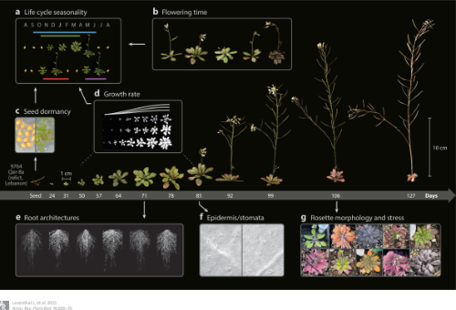

Figure 1 Click to view

[Download as PowerPoint](https://www.annualreviews.org/docserver/fulltext/arplant/76/1/pp760605.f1.ppt?mimeType=application/vnd.ms-powerpoint)

The last two decades have seen a surge of research aimed at understanding species adaptation through a combination of new molecular biology, genomics, and evolutionary ecology research. In this review, we aim to summarize recent advancements in our understanding of Arabidopsis ecology and evolution, focusing on how the genomics of hundreds to thousands of wild populations has revealed insights on its evolutionary history, how association mapping has revealed general principles of inheritance in functional complex traits, and how combining genomics with field common garden experiments has led to a comprehensive understanding of climate adaptation, ultimately bringing us closer to answering some of the pressing questions on global change biology.

2. NATURAL VARIATION EXPLODES: GLOBAL COLLECTIONS OF GENOMES

Go to section...

As the popularity of Arabidopsis grew and sequencing methodologies advanced, new collections of accessions across Arabidopsis's range permitted the study of natural genetic variation. These efforts resulted in the establishment and maintenance of one of the largest seed stocks for a single species. To gain a sense of the magnitude of resources available, the Arabidopsis Biological Resource Center (ABRC; https://abrc.osu.edu/ ) in the United States has (as of June 2024) 694,472 seed stocks derived from over 6,946 accessions collected worldwide [not including the European Arabidopsis Stock Centre (NASC) and RIKEN BioResource Research Center in Japan]. Likewise, the potential for using natural variation to characterize the genetic basis of traits led to the development of the largest genomic resource to date after the 1000 Genomes Project (which cataloged human genomes): the A. thaliana 1001 Genomes Project (1, 165). Below, we first describe how these genetic resources enable the study of demographic history, biogeography, and genomic evolution through time. Then we highlight the general insights gained from combining phenotypes and genotypes to understand the genetic basis of natural variation. These advances are key building blocks to better understanding genomic adaptation across the climatic range of a species.

2.1. Biogeography and Demography: The 1001 Genomes, Relicts, and Out of Africa Events

By the 2000s, the geographic distribution of Arabidopsis was well established, and the climatic range was well characterized (71). Collections from the wild spanned latitudes of North Africa to those of Scandinavia and longitudes of the United Kingdom and Western Europe to those of the Balkans and Middle East, extending as far as western Tibet (84, 125) ( Figure 2a ). Early population genetic data of a few restriction enzyme molecular markers showed no association with geography in samples in Northern Europe and the United States (21), but when the number of restriction molecular markers and populations sampled increased, a differentiation between Southern European and Eurasian specimens was detected, leading to the hypothesis that Northern Europe was recolonized by both Asian populations and those from Southern European glacial refugia (142). Likewise, the relationships among accessions did not fit a classic bifurcating pattern of evolution, as accessions from similar geographic locations were not always the most closely related. This evidence foreshadowed a complex demographic history involving strong population genetic structure; glacial refugial populations; and postglacial expansion, migration, admixture, and gene flow.

Figure 2 Arabidopsis thaliana’s global distribution and history. (a) Global distribution of Arabidopsis based on observations from the Global Biodiversity Information Facility (GBIF; https://www.gbif.org/ ) (indicated by exes), with samples overlayed from the 1001 Genomes Project ( https://1001genomes.org ; 1) (colored and black circles), the regional mapping (RegMap) panel (72) (gray circles), and Reference 43 (brown squares). The background map color is based on a MaxEnt climate niche model fitted with GBIF observations within the native range [following https://www.github.org/moiexpositoalonsolab/arabidopsisrange (45)]. Data from References 1, 27, 43, 47, 49, 77, 90, and 174. Dotted arrows indicate migrations from the last several centuries, while solid arrows indicate ancient migrations. (b) A magnified view of the native range of most samples and populations (indicated by the rectangle in panel a). Colors indicate genetic clusters from Reference 49 and added African herbaria samples from Reference 43. (c) Diagram (not to scale) based on quantitative data of the demographic and migratory history of Arabidopsis. Relationships depicted among European populations in the last 1,000 years are putative, and population size as line thickness is approximate. See also the interactive map of natural accession projects for A. thaliana ( https://tinyurl.com/47ds8t7z ).

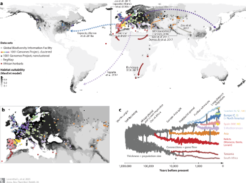

Figure 2 Click to view

[Download as PowerPoint](https://www.annualreviews.org/docserver/fulltext/arplant/76/1/pp760605.f2.ppt?mimeType=application/vnd.ms-powerpoint)

The development of single-nucleotide polymorphism (SNP) genotyping methods (112, 163) enabled the discovery of common genetic variation across populations (34, 80), leading to the design of genotyping arrays with increasing numbers of SNPs and accessions. This allowed researchers to identify genotyping arrays of more SNPs and accessions from global sets of Arabidopsis, which uncovered major haplogroups across Eurasia and a selfing rate of 97% (119), to local sets of over 1,000 individuals, which were genotyped to define within-population dynamics maintaining diversity, including surprisingly high cross-pollination in dense rural stands that reduced selfing rates up to 86% (24). SNP genotyping methods led to the regional mapping (RegMap) panel, based on a 250,000 SNP-chip (34, 80) for 1,307 worldwide accessions, which provided the resolution to further characterize the population structure and Eurasian groupings, identifying the first genome-wide signals of natural selection through significantly elevated genetic differentiation or diversity regions, that is, selective sweeps (72). This permitted forward genetic screening of traits using genome-wide associations (GWAs) across measured phenotypes grown in indoor conditions (14) (see Section 2.2). Genomic diversity exploration culminated in whole-genome sequencing (WGS), from tilling (34) to short-read Illumina sequencing (115). This enabled the formation of the landmark 1001 Genomes Project, where WGS was applied to over 1,135 accessions of Arabidopsis, which contributed to the most comprehensive data set yet of over 10 million SNPs and small indels (i.e., about 1 variant in ∼10 bp) to aid in the understanding of Arabidopsis functional genomics and natural history with increased emphasis on geographic representation (1, 31, 57, 96, 138).

Applying evolutionary population genetic models to vast genomic data sets allowed for the compiling of global relationships and the demography of different populations through history ( Figure 2 ). The most immediate observation analyzing 1,135 genomes through ADMIXTURE clustering was the existence of an old and highly diverse Arabidopsis lineage in the Levant, North Africa, and islands off the coast of Africa and in the Mediterranean (including Cape Verde, the Canary Islands, Madeira, the Iberian Peninsula, Sicily, Morocco, Algeria, Lebanon) ( Figure 2b ). This group was coined the relicts, which alludes to their likely history as refugial populations during the last glacial periods (65). While this group had been noted in regional analyses to be common in North African and Iberian samples (27), their diversity and relevance in the evolutionary history of Arabidopsis had been underestimated in global analyses. Relict populations are typically found in montane native environments with low human footprints, such as the xeric Mediterranean shrublands of Spain, the Moroccan Atlas Mountains, or mountain ranges in the Levant, where microhabitat selection such as rocky outcrops or north-facing sides of oaks provide increased moisture. Although these environments now typically have highly variable precipitation patterns and warm temperatures, they were climatic refugia during Pleistocene glacial periods (1, 27, 156). The biogeographic and demographic histories of populations in a species shed light on adaptive history and adaptive potentials. For instance, some adaptive traits, such as the development of trichomes on fruits, which confer abiotic and biotic stress tolerance, have been identified exclusively in Iberian relict lineages, highlighting how historical factors influence subsequent adaptations (12, 13).

Coalescent genomic models that reconstruct past demographic processes (136) corroborated the theory that relicts were more abundant prior to and during the last ice age, in which they likely split into several groups in Africa, Asia, and Europe and experienced population decline in the last glacial period and the present (1, 43, 49) ( Figure 2a ). This contradicted the notion that Arabidopsis was only a rapidly spreading weed related to agricultural expansion into Europe (54). In fact, relict populations from Iberia likely originated from Moroccan and other African populations about 120–90 kya, during the wet Abbassia Pluvial. These Iberian relicts later admixed with nonrelicts expanding into Western Europe after the postagricultural expansion 10 kya (1, 54, 90), but likely even prior to that at ∼40 kya (43, 55), suggesting that multiple out-of-Africa events occurred (1, 43, 90).

An important technological advancement in sequencing ancient DNA enabled the sequencing of herbarium specimens (43, 47) collected from Africa and showed that lineages from Tanzania (Mount Kilimanjaro and Mount Meru) and South Africa ( Figure 2c ) were most closely related to relicts of the Mediterranean (43). This ancient genetic diversity in Africa suggests that the speciation event from Arabidopsis lyrata occurred in Africa, as well as the later transition to self-compatibility (∼1–0.5 mya), after which the effective population size declined (43). These long-isolated relict populations present interesting evolutionary experiments that will be fruitful to explore in the future, as exemplified in Cape Verde Island relicts, which present evidence of independent evolution of early flowering as well as nutrient acquisition in volcanic soils (56, 153).

Northern populations of Arabidopsis, particularly in Sweden, exhibit high genetic variation and linkage disequilibrium (96), even higher than Central European populations (1), which challenges the hypothesis of genetic diversity decay due to founder effects during northward postglacial colonization from Africa and the Levant (65). Scandinavian populations, adapted to long winters and persistent snowpack, showed gene flow connections with Mediterranean populations, suggesting ancestral admixture or allele sorting of adaptive variations (42, 49, 90). East Asian populations, highly divergent in the 1001 Genomes panel, were found to be ancient colonizations in the native range rather than recent migrations ( Figure 2a ), likely originating from North Africa before the Last Glacial Maximum (174).

Arabidopsis has recently spread to nearly all continents ( Figure 2 ), with North American populations likely originating from a single expansion event from the southern United Kingdom during European colonialism in the 1600s (1, 63, 119), as evidenced by whole-genome variation in historical specimens (47) ( Figure 2a ). Similar genetic bottlenecks were observed in Patagonia, Argentina, indicating a separate migration from the southern Mediterranean (77), while Japanese populations resembled Central European populations, suggesting another recent colonization (83). Populations in New Zealand and Australia remain unsequenced and speculative in origin.

2.2. Mapping Natural Variation: The Explosion of Genome-Wide Association Studies

Natural genetic variation across the native range has been the greatest resource and inspiration for Arabidopsis geneticists. QTL populations—created from crossing laboratory accessions with wild-type populations from faraway regions [e.g., Col-0 and Ler originated in Germany and were crossed with Cvi (Cape Verde Islands) or with Sha (Shahdara, Pamir-Alay, Tajikistan)]—provided a fruitful framework to conduct forward genetics trait mapping, identify genes underlying extreme variation in traits (reviewed in 5, 8, 84), and test evolutionary hypotheses about the genetic architecture of ecologically important traits (e.g., antagonistic pleiotropy, epistasis, and gene–environment interactions of major loci). The new genomic resources available from the 1001 Genomes Project catalyzed the use of genome-wide association (GWA) study for trait mapping in Arabidopsis (14, 154). GWA approaches offer the possibility of identifying the genetic basis of traits at a finer resolution than QTL trait mapping, as they associate millions of naturally occurring genetic variants with phenotypes across hundreds to thousands of accessions. GWAs also leverage historical recombination, typically leading to mapping narrower genomic regions (the strengths and weaknesses of GWAs and QTLs are reviewed in 18, 20, 164, 166). The first keystone GWA in Arabidopsis using the RegMap collection (14, 154) showcased the power of mapping approaches in plants, identifying bona fide genes with functions that are likely responsible for a particular phenotype. Thanks to decades-long research in gene cloning (164), genes of known function, such as disease response (RPM1, RPS2), lesioning (ACD6), flowering repressors [FRIGIDA (FRI) and FLOWERING LOCUS C (FLC)], and seed dormancy [DELAY OF GERMINATION1 (DOG1)] were among those corroborated with GWAs. These were also the first investigations into the genetic architecture of many different classes of traits in plants, which provided insight into how numerous the loci affecting trait variation are and how these loci are distributed along the genome.

The success of GWAs in Arabidopsis established several stark differences from results from GWAs in humans. First, sample sizes of hundreds, not thousands, of plants are sufficient to detect causal genes (validated molecularly) in Arabidopsis (14, 154). Second, there are many common alleles of major effect in Arabidopsis, which is uncommon in human studies, as major-effect alleles are subject to purifying selection and are thus rare (14, 154). Third, despite linkage disequilibrium in Arabidopsis being a similar order of magnitude [∼10 kb (80)] to that in humans, the strong geographic differentiation among populations (i.e., population structure) and/or positive local selection forces acting in multiple loci generates so-called mountain range peaks in Manhattan plots rather than sharp peaks. This confounder does not come from a lack of environmental control when measuring phenotypes, as is the case in human studies, but rather comes from nonindependence in genetic variants genome-wide due to demographic and selective forces, which also require accounting for relatedness among individuals with mixed models (171) and the careful interpretation of top loci (see caveats in 14, 20, 134, 164, 166).

One key advantage of GWAs in Arabidopsis is that the 1001 Genomes Project (1) sequenced inbred lines that are maintained in seed stocks ( https://abrc.osu.edu/stocks/465820 ), so they can be grown and phenotyped repeatedly in various environments or conditions (see Section 3). Web portals can even run GWAs given a set of uploaded phenotypes [GWAPP (141), easyGWAS (62)], and results can be made available in portals under the 1001 Genomes umbrella [ https://1001genomes.org ; AraPheno (140), AraGWAS (155)]. We have summarized a subset of the over 1,800 traits from AraGWAS (462 available as of June 2024) and other published studies (130, 162) to learn about the general patterns of heritability (h<sup>2</sup>) across the global distribution of Arabidopsis (not within a single population) and the relative contributions of major- and minor-effect loci to heritability ( Figure 3 ). Although many GWAs yield significant hits, one immediate observation is that while heritability may be high for many traits, few traits are truly monogenic, with most traits having partial to completely polygenic architectures (i.e., a moderate to large proportion of trait variation explained by many small effect loci). Traits with high polygenicity, even when reasonably heritable (h <sup>2</sup> of ∼0.5), may have low power to detect loci with 1,000 genomes [<0.2 for haplotype-based GWA or ∼0 for SNP-based GWA (170)]—a conundrum coined in human studies as missing heritability (2, 161). This was reconciled by understanding that certain genomic architectures do not fit standard GWA methods, such as contributions of rare variants or gene–environment interactions (58), and by the development of new statistical techniques that jointly fit large or small effects of genome-wide variants, which permitted the explanation of the majority of heritability as well as the prediction of accession phenotypes through polygenic scores (2, 172) ( Figure 3a ).

Figure 3 The genomic basis of natural variation across Arabidopsis traits. (a) Single-nucleotide polymorphism–based narrow-sense heritability estimates from Reference 130 for 460 traits collected from the public database AraPheno, Reference 162, and other published studies. Narrow-sense heritability was estimated as the proportion of variance explained (PVE) using a Bayesian linear sparse mixed-model genome-wide association study. Circle sizes are relative to the number of accessions used in the study. (b) Heritability as PVE plotted against an estimation of polygenicity (1-PGE), which is the remaining proportion of variation not explained by major-effect loci (PGE). When PGE is high, a high amount of the variation is explained by major-effect loci; when it is low, major-effect loci explain less of the variation, indicating a more polygenic architecture. We have inverted the axis to be 1-PGE so that high values indicate high polygenicity (i.e., low PGE indicates that major-effect loci account for little of the explained phenotypic variation) and low values indicate low polygenicity (i.e., high PGE indicates that major-effect loci account for much of the explained phenotypic variation). Circle sizes are relative to the number of accessions used in the study.

[figure not shown]

Figure 3 Click to view

[Download as PowerPoint](https://www.annualreviews.org/docserver/fulltext/arplant/76/1/pp760605.f3.ppt?mimeType=application/vnd.ms-powerpoint)

After clustering traits by life stage, organ, and morphology, we observe that the most heritable traits are connected with flowering time [interquartile range (IQR) h<sup>2</sup> = 85–98%], followed by seed germination and dormancy (IQR h<sup>2</sup> = 72–96%), development and growth (IQR h<sup>2</sup> = 42–92%), rosette morphology (IQR h<sup>2</sup> = 25–76%), root architecture (IQR h<sup>2</sup> = 23–82%), epidermal stomata traits (IQR h<sup>2</sup> = 16–31%), and fitness-related traits such as survival and fecundity (IQR h<sup>2</sup> = 17–64%). It appears that there is an inverse relationship between heritability and the fraction of heritability contributed by many small loci (a proxy of polygenicity), whereby many traits have either (a) low to moderate heritability (h<sup>2</sup> < 0.5), and most of it is explained by many small-effect loci (1-PGE > 0.5) (126 traits; enriched on root), or (b) high heritability (h<sup>2</sup> > 0.75), and most of it is explained by large-effect loci (37 traits; enriched in flowering) ( Figure 3b ). Fewer cases have moderate to high heritability (h<sup>2</sup> > 0.5) and are also mostly explained by many small-effect loci (29 traits; enriched on seed dormancy rosette morphology and water use), whereas almost no trait has the opposite pattern of low heritability explained by large-effect loci ( Figure 3b ). These large-scale GWA studies also show widespread pleiotropy among traits even when measured in independent indoor experiments. For instance, genetic correlation is strong between (a) water-use efficiency proxy (δ<sup>13</sup>C) and flowering time measured at 16°C growth (rg = 0.34), (b) percentage of germination and root angle (rg = 0.64), and (c) growth rate and stomatal index (rg = 0.44) calculated through a multiresponse linear mixed model informed by genome-wide relationship matrices (130).

In the post-GWA era, we predict two directions will be most prevalent to generate new questions about the natural variation: How can we assign a causal functional meaning to the thousands of genomic regions associated with traits, and what is their evolutionary relevance?

GWA peaks most often cannot pinpoint causal variants. They should rather be used as the basis to create further hypotheses to understand the molecular basis of loci. Several technologies may narrow down the precise genetic sequences controlling a trait. First, high-throughput validation could be achieved through systematic testing of knockout mutant libraries, for instance, using insertion mutagenesis collections at a large scale (e.g., Salk T-DNA) or new CRISPR-Cas9 approaches that permit mutation engineering beyond knockouts (173), combinations of mutations (150), or studies of cis-elements controlling expression in a quantitative fashion (129). Second, in addition to gene editing, functional data sets such as expression (79) or DNA accessibility atlases (114), connections with certain genomic features or cell types (111), and even single-cell expression atlases (91) may help ascertain which loci identified in GWAs have a high likelihood to be causal. Third, upcoming reference genome-free or pangenomic technologies may uncover the true causal variants by discovering variations beyond SNPs (75, 94, 124, 162). Furthermore, the power of GWA could be enhanced by focusing on regional populations, which would reduce the complexity of genetic structures and increase allele frequencies, as geographic heterogeneity of genetic diversity explains some of the variation in genomic architectures observed across studies (12, 96, 97, 151).

Ultimately a deeper understanding of GWA results will require an evolutionary lens. A population genetic evolutionary model of human GWAs suggests that most human traits are under a pleiotropy stabilizing selection model, where large effects are moving multiple traits away from the optimum, which are thus negatively selected and relegated to low frequencies (144). In Arabidopsis, we need to answer why common variants sometimes have a large effect, why heritability varies across broad classes of traits, why there is an inverse relationship with polygenicity, and how extensive pleiotropy is across genetic architectures even in seemingly unrelated traits. To address these questions, we will likely need to invoke and study different evolutionary mechanisms, such as the pervasive local adaptation to the environment, involving the coordinated divergence of traits. Fortunately, knowledge of the climate of origin of different accessions as well as the ability to grow experimentally hundreds or thousands of accessions in realistic environments can be helpful to provide an evolutionary context to GWA results (see Section 3.1). For instance, the geography and climate where an accession is collected carries a wealth of evolutionary information, so researchers have therefore used climate of origin as a phenotype in a GWA or scanned for overly high allelic divergence across geographic regions (46, 66, 72), and fitness traits used for GWA have revealed peaks associated with those geographic and climatic signals (46).

3. ADAPTIVE INSIGHT FROM OUTDOOR COMMON GARDEN EXPERIMENTS

Go to section...

Arabidopsis's vast natural variation, genomic data sets, decades of functional knowledge, and well-studied genetic basis of traits, make it an ideal experimental model system in evolutionary ecology to understand the genetic basis of local adaptation (106, 117, 167). Simply put, one can directly assess whether a genotype is adapted to an environment by planting, observing, and comparing success across plants (67). This differs from inferences from indoor common gardens, where local adaptation insights may be indirectly gained by linking phenotypes with the climate of origin of an accession. Because we know that Arabidopsis populations have been shaped by various migrations, demographic expansions and contractions, and admixture (see Section 2.1), such inferences should be validated in the field. Outdoor common garden experiments are the gold standard to quantify natural selection and local adaptation to an environment, as relative fitness in an outdoor common garden is directly associated with a trait or a genotype. Common gardens have also aided in the identification of many pertinent genes ( Supplemental Table 1 ). The first outdoor common garden with Arabidopsis was conducted in 1993 (101), and since then we have identified 73 Arabidopsis outdoor common gardens ( Table 1 ; Supplemental Table 2 ) (see Reference 9, a guide to field experiments in The Arabidopsis Book). Common garden experiments have a century-old, rich history (35, 157), and local adaptation has been validated in the majority of plant species studied in the last few decades (70, 92). Even when traits are not measured, researchers quantify local adaptation as the difference in relative fitness between local and nonlocal populations: agnostic to actual trait variation. The last 30 years of common gardens have shown that local adaptation–driven differences in fitness can be so extreme that some populations are unable to survive at distant locations within the species’ range (95) and that adaptational lags may be common (168), providing an alarming warning for future adaptation to global change.

##### Table 1

Summary of outdoor common gardens using Arabidopsis in the last 30 years a

Toggle display: Table 1 [Open Table 1 fullscreen](https://www.annualreviews.org/content/table/10.1146/annurev-arplant-071123-095146.t1?fmt=ahah&fullscreen=true&lang=en)

[output not shown]

aWe summarize a subset of outdoor common garden experiments which focus on genotyped lines used in mapping studies. We include the year(s) the experiment was conducted; the number of years the experiment occurred, accessions used, and sites; the general locations of the experiment; and the altitude, primary discovery, and reference(s). See Supplemental Table 2 for an extended list of outdoor common garden experiments.

bYear of planting not given; year indicates publication date.

cWild populations.

dWorldwide or regional collection included in Arabidopsis Biological Resource Center.

eRecombinant inbred lines.

fWorldwide or regional collection.

gWorldwide or regional collection included in RegMap.

hWorldwide or regional collection included in 1001 Genomes.

iPlants from a single population.

Outdoor common gardens employ various designs to test different aspects of adaptation, from using knockouts of photoperiod or flowering genes to understand seasonal adaptation (169) to testing RILs between two ecotypes in reciprocal cold versus warm environments (4) to growing large swaths of accessions in several countries across Eurasia (46, 50; https://grene-net.org/ ) to designing a manipulative outdoor rainfall gradient within one location to disentangle direct effects of a climatic variable in population fitness and adaptation (93) ( Figure 4e ; Table 1 ; Supplemental Table 2 ). Much literature has dealt with plant–insect and plant–pathogen interactions in Arabidopsis outdoor common gardens (see 76, 78, 101, 109, 110, 135). Here, we focus instead on the results of environmental (i.e., abiotic) adaptation from trait variation across the geographic range of Arabidopsis. First, we begin by broadly summarizing the evidence of natural selection across experiments and then describe how natural selection varies across phenotypes and across geographic regions. Second, we describe general principles of local adaptation, its genetic basis, and how this knowledge is relevant to understanding future climate change responses.

Figure 4 Outdoor field experiments of Arabidopsis thaliana across its native and nonnative distribution highlighting different experimental designs, environmental conditions, and unique ecotypes and morphologies. (a) Rainout shelters in Germany (top left) and Spain (bottom left). High-density populations with no water stress (middle) and high water stress (right). Photos adapted from Reference 46. (b) Independent, randomized block design in Lille, France (26). Field location of common garden (left). Example blocks from the field site (middle). Individual rosette in a pot (right). Photos provided by Fabrice Roux. (c) Herbivore exclusion shelters in Montpellier, France (123). Field site in winter (top left) and spring (bottom left). View inside a herbivory tent (middle). An herbivore at work (right). Photos provided by François Vasseur. (d) Reciprocal transplant study sites in Sweden (left) and Italy (center) and a close-up of rosettes with plant tags in Castelnuovo di Porto, Italy (right) (4). Photos provided by Jon Ågren. (e) Precipitation addition sprinkler and rainfall reduction shelter within the field design (left) (93). Example tray with individual plants in each pot in high–drought stress conditions (middle). Single rosette on the first day of flowering in stress conditions (right). Photos provided by Laura Leventhal, Megan Ruffley, and Moises Exposito-Alonso. (f) Two of five common garden sites in Valencia, Spain (left), and Cologne, Germany (center), and close-ups of the rosettes from Spain (top right) and Germany (bottom right) (50). Photos provided by Johanna Schmitt. (g) High-elevation (bottom left) and low-elevation (top left) field sites in Spain (48). Example pots from the low-elevation site (center) and a close up of high-density rosettes in a pot (right). Photos provided by Xavier Picó and Moises Exposito-Alonso. (h) Rooftop garden in Toronto, Canada, covered in snow (left) and after snowmelt in spring (left center). Birds-eye view of Arabidopsis in pots in spring (bottom center right). Photos provided by Amanda Peake and John Stinchcombe. Close up of three morphologically distinct rosettes (top center right, top right, and bottom right) (133). Photos provided by John Stinchcombe. (i) Field sites from GrENE-net Consortium in Brixen im Thale, Austria (top left); Freising, Germany (top center); Golm, Germany (top right); Parainen, Finland (bottom left); Davis, California, United States (bottom center); and Madrid, Spain (bottom right). Photos provided by GrENE-net Consortium.

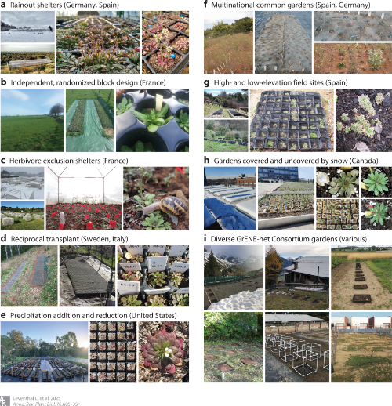

Figure 4 Click to view

[Download as PowerPoint](https://www.annualreviews.org/docserver/fulltext/arplant/76/1/pp760605.f4.ppt?mimeType=application/vnd.ms-powerpoint)

3.1. Patterns of Phenotypic Selection from Arabidopsis Common Gardens

The first question asked when studying natural variation of Arabidopsis accessions in field experiments is whether different accessions vary in overall fitness and whether this is correlated with a trait of interest (i.e., natural selection). A common theoretical formulation allows the comparison of studies using the same standardization (87) whereby a selection coefficient is expressed as a change in relative fitness with respect to a standard deviation of a phenotype. Significant positive or negative values evidence directional natural selection. The framework extends to multiple traits and nonlinear relationships, so we may also find evidence for a central optimal trait—stabilizing selection—or the opposite, where trait extremes are selected—disruptive selection. If a trait is heritable, then understanding natural selection provides insight into how a population will evolve over time in response to such selective pressures (82, 87).

3.1.1. Dormancy and germination.

The first stage at which natural selection can act on Arabidopsis populations is the timing of seasonal germination determined, controlled, and repressed by seed dormancy. Germination timing depends on primary dormancy, which is set while seed embryos develop and mature, and secondary dormancy, which is set in response to the environment experienced after seeds are dispersed (16, 17, 22, 137). The best-known life cycle of Arabidopsis is the fast-growing Col-0 accession typically grown in the lab, which has high germinability (>90%) and can complete a cycle in 4 weeks. Col-0 was originally collected in Germany, where high germination is favorable in human-disturbed, nutrient-rich habitats and humid temperatures, which select for ruderal plants with rapid annual life cycles. Seed germination rates are generally high in temperate populations. Sequential field-sowing experiments conducted from June to November in the oceanic temperate climate of Providence, Rhode Island (United States), which resembles the climate of Central Europe, revealed that these ruderal populations had strong selection on germination timing, leading to the near fixation of dormant alleles at two major QTLs for dormancy within a single generation. In this study, weak primary dormancy still timed most germination around September, which allowed plants to achieve the highest fruit production (explaining 30% of fitness variance). This pattern aligns with a stabilizing selection optimum for early fall when seeds were dispersed in summer. However, when seeds were dispersed in autumn, directional selection favored early germination (41).

Dormancy and germination are highly variable across accessions of Arabidopsis (100, 108). Laboratory measurements of dormancy across global accessions show that there is a latitudinal gradient in dormancy, where high dormancy of accessions correlates with low summer precipitation and high mean annual temperature at the collection site of origin (37, 86, 99, 160). To understand how this variation leads to local adaptation across different geographic populations and climates, dormancy and germination have been studied in a number of outdoor common gardens (3, 48, 59, 103, 120, 121, 139).

Northern European environments, where winter onset occurs in early fall with constant snowpack from November to April (42), are expected to select for early germination. If germination occurs too late, snowfall may cover emerging seedlings and become fatal. Researchers have measured germination proportion and timing along with scores of mortality and fruit fecundity in field experiments planting RILs of Swedish × Italian lines and the parental lines in Rødåsen (northern Sweden). This confirmed that such cold climates impose directional selection for low fall dormancy and thus high germination, which presumably allows correct germination timing and high establishment (120). These experiments were conducted repeatedly over multiple years, and, depending on the year of the experiment, there was selection for early germination, late germination, and, for one year, stabilizing selection, and in all cases the local parent had superior fitness, suggesting local adaptation through germination timing (121). QTL analyses of fitness in Rødåsen overlapped with well-known genes, including DOG1, 1 of the 11 known loci from dormancy studies in the laboratory (6, 19, 148), reinforcing the existence of natural selection on dormancy at the genetic level. In northern latitudes, germinating after the snowmelt (∼April–May) may also be deadly, as there might not be enough time for spring germinants to successfully complete their cycle. Consequently, Swedish accessions with functional DOG1 variants appear to repress germination in laboratory germination assays after exposing seeds to cold periods (4°C or 10°C) (100), suggesting an adaptive acquisition of cold-driven secondary dormancy to prevent winter and spring germination.

On the other latitudinal edge of the Arabidopsis range, for the coastal Mediterranean and African populations, which experience dry and warm summers but mild winters (>0°C), germination is expected to be delayed. Reciprocal fall planting experiments of the Swedish × Italian RILs in Castelnuovo di Porto near Rome (Italy) showed directional selection favoring high dormancy (<7% germination) (121). This calls to mind desert bloom plants, which remain dormant in the soil for several years when conditions are suitable, which is common in Mediterranean climates with highly variable interannual precipitation patterns (36). Although high dormancy was adaptive, evidence for timing of germination being dependent on the fitness component used (i.e., total fitness, fecundity, establishment, and survival) suggested a more complex natural selection where bet-hedging, density-dependent effects play a role in addition to environmental cues (120). In Mediterranean and African regions, germinating during summer is deadly, while winters are mild. In agreement, weak or null alleles of dog1 that permit germination induction in mildly cold conditions are found in such southern range populations. Field experiments also corroborate this: Seed planting of 42 regional Iberian accessions in Grazalema (southern Spain) during late December had perfectly high germination and recruitment in two consecutive years (69–71%) (48). Instead, to prevent germination during summer or early fall, accessions acquire secondary dormancy induced by heat and dry conditions, as shown by the reduced germination in laboratory assays after exposing seeds to warm (20°C or 30°C) and low water potential (−1.0 to 1.2 MPa) solutions (15, 108).

Across these climatically contrasting geographic regions, diverse seed behaviors are likely controlled by multiple DOG genes, and while DOG1 is the most well studied, understanding the environmentally driven dormancy mechanisms of other genes and their interactions will be illuminating (6, 19, 131, 152).

3.1.2. Flowering time.

In northern regions, the ancestral cold-repressed flowering pathway controlled by FLC and FRI is a key adaptation to harsh winters to avoid flowering while it is too cold, too dark, or plants are under snow. The importance of vernalization for fitness in field experiments is patent. Fall seedling experiments in Oulu (Finland) with over 50 global accessions found strong directional selection coefficients for late flowering, which produced more fruits, across diverse accessions (51). Swedish × Italian accession RILs planted in fall from seed in Rødåsen (Sweden) also showed selection coefficients for late flowering (3). The days to flowering since fall germination in Sweden were typically >120 days (∼April–May), and the Italian parental line often died before reaching flowering (mortality rates were ∼40–100% across 5 years), in contrast to the high survival rates of the Swedish parental line (mortality ∼0–70%). QTL mapping narrowed down several loci involved in field fitness, including FLC and VERNALIZATION INSENSITIVE 3 (VIN3) (3, 40, 60). Coding and noncoding variation across accessions in FLC and increased expression of VIN3, which promotes epigenetic silencing and expression of FLC, carefully curate a gradient in flowering time in northern environments, gene expression changes that have directly been measured in field experiments in southern (Ullstorp) and northern (Ramsta) Sweden (42, 69).

Natural genetic variation in FLC and FRI have explained much of the gradient in early to late flowering time in natural populations increasing with latitude in Eurasia (29, 143, 149), and early studies of natural variation in Arabidopsis found that the requirement for vernalization is one of the strongest qualitative differences found across Arabidopsis populations and the key distinction between winter and spring/summer annuals (68, 117).

The diversity of flowering observed across a latitude gradient in Europe is found within the Mediterranean and African regions along an altitudinal gradient, where lowlands and southernmost regions have extremely early flowering, such as the famous relict Cvi from the Cape Verde Islands (6911) or IP-Vid-1 (9512) from southern Portugal, while montane regions have vernalization-controlled late flowering, such as relict IP-Sne-0 from the Sierra Nevada mountains in Spain (9583) collected at ∼2,500 m above sea level. From coastal lowlands to highlands of the Iberian plateau, fri alleles have been observed at low latitudes (<800 m), whereas functional FRI populations that require vernalization are found at high elevations (105). Several Southern European field experiments have corroborated that natural selection influences flowering time, generally supporting directional selection for early flowering in lowland regions and late flowering in the highlands: In the lowland Italian field site near Rome (Central Italy) with RILs, plants accelerated their life cycle, with much earlier flowering across both Italian and Swedish parents (∼40–80 days, starting in January for Italian accessions), which led to an outsized survival rate and fecundity of the Italian parent and the correlation of flowering time of RILs with fitness (3, 4). Fall seedling transplants of 150 accessions in Valencia (southeastern Spain) showed correlations with early flowering (51). A fall seed planting population cohort of 517 accessions in Madrid (Central Spain) showed a large gradient of flowering from January to March, which supported a significant correlation of lifetime fitness with early flowering (46). And 5 out of 6 fall and winter seed plantings with 42 regional Iberian accessions in Grazalema (southern Spain) corroborated this correlation (48). However, high-altitude experiments in the Sierra Nevada mountains near Granada (1,650 m, southern Spain) showed 100% mortality in winter cohort sowings (December–February) and 2%, 26%, and 41% survivorship in October fall sowings in 3 consecutive seasons; and they required a late flowering time of ∼170 days after germination (∼May) (48). Targeted genetic studies of FRI and FLC show interesting novel functional variants and epistatic interactions not found elsewhere in the distribution (104), and GWA of 176 regional Iberian accessions planted in Grazalema (southern Spain) uncovered other well-known genes involved in the vernalization pathway but also novel functional regional variants: TWIN SISTER OF FT (TSF), FRIGIDA‐like 1 (FRL1), and FLOWERING LOCUS T (FT), which is a downstream integrator of FLC, as well as the photoperiod, ambient temperature, and autonomous pathway (151).

In southern climates, natural selection over flowering time is more complex, as different field experiments and seasons have identified variable correlations of fitness with early or late flowering. For instance, experiments in Lille (France) had positive, negative, and nonsignificant correlations, depending on the plant crowding in pots (53). The experiments in Grazalema (southern Spain), with an extensive 279 regional accessions, showed correlation of fitness with late flowering during one year (99) and with early flowering four other years for a subset of 42 diverse accessions (46, 48). Experiments in Grazalema (southern Spain) and Madrid (Central Spain) both showed that if fitness is partitioned between survival and fecundity, survival correlates with early flowering while fecundity correlates with late flowering—suggesting trade-offs between life stages. One may then speculate that interannual variation in natural selection may be due to variable precipitation patterns, which lead to selection of late flowering in wet high-survival years, while dry years would select for early flowering, although this hypothesis needs to be further tested (46, 48, 130). Together with its ancestral demographic history harboring relict populations, temporally varying directional natural selection could also be one of the evolutionary mechanisms that explain the coexistence of both winter and spring cohorts in Iberian populations (116), although it also indicates a potentially complex cross-pleiotropy between flowering and germination genes (15) or with other traits involved in growth and the development of above- and belowground and water relations (130).

3.1.3. Growth, water-use efficiency, stress tolerance, and belowground traits.

The length of a plant's life cycle strongly conditions other developmental and ecophysiological functional traits, which are important for adaptation to harsh and variable climatic conditions. Trait ecology theory—including the fast–slow plant economic spectrum (38), ruderal to stress-tolerant [CSR classification (61)], and escape versus avoid stress gradients (98)—have been applied to Arabidopsis as a framework to explain variability in the life cycle and its connection with ecophysiological traits. In essence, these frameworks predict that a slow, conservative plant growth behavior permits efficient water and resource allocation that increases resilience and tolerance to several stressors. By contrast, an acquisitive growth behavior allows for short life cycles that allow for the escape of seasonal stressors by finalizing flowering before the onset of stress. An intermediate fast yet vigorous growth may be the most generalist strategy for ruderal populations. Unsurprisingly, ruderal phenotypes are clearly selected in field experiments independently of location. In 84% (21 out of 25) of experimental prereproductive selection coefficient estimates, there was positive directional selection for increased growth and development (e.g., larger rosette diameters, longer leaves), and in 90% (18 out of 20) of postreproductive selection coefficient estimates, there was positive directional selection for growth (e.g., stem height, number of inflorescence branches). Clearly there are traits under selection other than germination and flowering time in ruderal environments; thus, the question is what other adaptations will contribute to local adaptation in extreme environments.

Leaf mass area, leaf nitrogen content, photosynthesis (Fv/Fm), stomatal density and size, and water-use efficiency (δ<sup>13</sup>C) ( Figure 3 ) have been measured across Arabidopsis accessions, establishing a stress-tolerance gradient correlated with flowering time (39, 74, 102, 123, 159). Although one might expect southern Mediterranean and African populations to be more tolerant to water stress given the region's acute and frequent droughts, the traits typically associated with resilience to water limitation (e.g., stomatal density, water-use efficiency) actually correlate with minimum annual temperature and latitude (39, 74, 102). Instead, analyses show that historical frequency of spring droughts correlate with abundant knockouts of several flowering pathways genes, leading to faster flowering, as seen in Cvi populations (56).

Dry-down experiments in indoor common gardens mimicking dry, cold seasons with Swedish × Italian RILs showed that northern populations had higher water-use efficiency than southern ones (107). Additionally, freezing conditions can induce cross-stress tolerance, improving plant survival under drought, as temperatures below 0°C cause plants to experience an equivalent physiological drought. In another indoor common garden experiment, the same RIL populations were exposed to cold by adding ice over rosettes and setting chamber temperature down to −7°C for over a week (113). This resulted in increased survival in Swedish parental lines (>80%) compared to the Italian lines (∼15%).

A dry-down experiment simulating a Mediterranean single rainfall followed by early terminal drought over six weeks in indoor common gardens with over 200 global accessions showed variation in survival from approximately 3 to 7 weeks among accessions. Although these conditions do not perfectly match outdoor conditions, survival in dry down significantly correlated with survival in Madrid (Spain) (46, 49). This experiment revealed a nonlinear convex relationship of survival with latitude, indicating increased survival in both southern and northern populations. However, water relation traits show low heritability and high polygenicity, complicating interpretations ( Figure 3 ). Polygenic scores of a GWA conducted on survival to dry down highlighted enrichments of adaptive alleles at the distribution's edges (49), but further research is needed to better understand mechanistically the genetic architecture of water-use efficiency (23). Root architecture, growth, and lateral root angle (e.g., shallow versus deep) correlate with latitude (shallow roots in the south, deep roots in the north) and are unexplored yet crucial for exploiting water in different soil types or periodicities (89). Even if these traits are measured ex situ ( Figure 3 ), we can compare them with fitness in 517 accessions in Madrid (Spain), which shows putative natural selection for increased stomatal density, root relative growth, and horizontal root angle for lifetime fitness (46, 130). To validate these in the future we will need direct observation in field conditions: approaches leveraging high-throughput multispectral imaging can quantify leaf economic spectrum variables similar to that used in an experiment in Montpellier (southern France) (123, 159), and manipulative precipitation experiments changing abundances and stochasticity of rainfall in California (United States) with in situ fitness and water-use measurements promise to illuminate these questions (93).

3.1.4. Beyond the weed; beyond the winter and spring annuals.

Although understandable, neither the classic weed concept of Arabidopsis nor the winter versus spring/summer annual classification of natural variation is accurate to understand the diversity of the species. After 20 years of natural variation studies, a wealth of field experiments clearly point to at least four overall strategies coinciding with regional climates (44): (a) Humid Central Europe and disturbed habitats have a prevalence of urban and ruderal weedy populations; (b) cold northern regions harbor strict winter-cycle plants, which, in addition, have strategies to cope with cold and water-limitation stress; (c) warm southern lowland regions of the Mediterranean and Africa have rapid cyclers with horizontal roots and seed bet-hedgers that escape drought seasons; and (d) southern mountainous regions harbor diverse populations of facultative spring and winter populations that may also have improved water relations to cope with long yet dry seasons.

3.2. From Local Adaptation Insights to Climate Change Studies

Due to clear patterns of natural selection on life history traits throughout the range, we expect local populations to have an advantage when grown in their home site. While common gardens have a long history (35, 157), the unique abundance of dozens of common gardens in Arabidopsis permits summarizing general inferences about local adaptation at a genomic level ( Figure 4 ; Table 1 ).

First, local adaptation is pervasive, with 74% of all common gardens detecting significant local advantage signals, but the strength of local adaptation is not symmetrical or equal across all environments. For instance, the classic Sweden and Italy reciprocal experiments showed that the strongest signal of local adaptation occurred when Italian populations grown in Sweden had an 80% fitness reduction compared to local populations and only a 40% fitness reduction for the reverse treatment. In another common garden study with a precipitation manipulation, transplants of a large panel of 517 Eurasian ecotypes in Spain in a low-rainfall treatment showed that ∼63% of (nonlocal) accessions failed to survive and set seed, while in Germany in a high-rainfall treatment mortality was extremely rare (∼0%) (46) ( Figure 4a ). These observations of mortality also parallel the heritability of fitness itself (see Figure 3 ), where the heritability of fitness (i.e., fitness differences explained genetically in the entire population) increases as the environmental stress becomes more intense (e.g., h<sup>2</sup> = 55.1% in Spain and 2.3% in Germany) (46). In agreement, but studying adaptation only at the fitness level without the help of genetics, research in other species summarized in a meta-analysis of 164 species shows a more intense signal of adaptation of local versus away populations toward the thermal edge of each of the species’ ranges (25).

Second, natural selection acts on plants throughout different stages in the lifetime of a plant, and thus the ability to detect estimates of local adaptation at the genotype or trait level may be dependent on the type of fitness estimates. For instance, in common gardens in Germany, approximately the center of the distribution, and Spain, close to the southern edge of Arabidopsis's range, researchers found that in the most extreme environment of Spain the heritability of survival was up to 50%, while the heritability of seed set was ∼0%, in contrast to the milder German environment where heritability of survival was ∼0% and seed set was ∼9% (46). In a different study in Spain, researchers determined that heritability estimates also differed for seed weight (h<sup>2</sup> = 87–93%), survival (h<sup>2</sup> = 0–11%), fecundity (h<sup>2</sup> = 0–5%), and overall fitness (h<sup>2</sup> = 0–6%) (103).

Third, local adaptation can emerge through two distinct genetic architectures: antagonistic pleiotropy and conditional neutrality. If it emerges through antagonistic pleiotropy, then the same gene variant increases fitness in a local environment but decreases fitness in a foreign environment, while conditional neutrality suggests that one gene variant is involved in increasing fitness in a local environment while remaining neutral in another. These diverging theories were addressed through four experimental sites in Europe (Valencia, Spain; Norwich, United Kingdom; and Halle and Cologne, Germany) at which the GWA showed allele associations with survival being positively correlated in one environment and negatively in another, suggesting a trade-off in allelic fitness effects (i.e., antagonistic pleiotropy), and alleles associated with fruit number were only significant in one environment, suggesting environment-specific effects (i.e., conditional neutrality) ( Figure 4f ). This approach was expanded when researchers tested the genetic architectures in the Germany/Spain Arabidopsis experiment where they found a SNP had a 6.7 odds ratio for being antagonistically pleiotropic versus conditionally neutral when comparing the two most extreme and natural climate pairs (Spain and low precipitation versus Germany and high precipitation), and a 1.31 odds ratio on average toward antagonistic pleiotropy between high- and low-precipitation treatments independent of location (46). While more research is needed to support this idea, one could interpret the prevalence of antagonistic pleiotropy in terms of adaptive loci influencing correlated traits in the slow–fast life history continuum and directional natural selection favoring one or the other extreme, depending on the environment.

We have learned that local adaptation is genetically based, common, and strongest in extreme environments. With impending climate change (73), understanding the genetic basis of local adaptation has gained a global policy relevance, as it may aid in understanding future (mal)adaptations of species and thus their potential response or demise (32). The deep genomic understanding of adaptation in Arabidopsis could make it a perfect model to study temporal changes in adaptation and potentially develop new predictive models. We conclude by describing local adaptation in the context of climate change and future steps.

Based on climate change trends projecting warmer and dryer conditions in most regions in Eurasia and North Africa, genomic prediction (or genomic offset) models of local adaptation suggest that populations from wet environments in Europe will lag behind in adaptation (32, 46). An analysis of fitness across four countries (Spain, Germany, the United Kingdom, and Finland) and the climate of origin of accessions indicated that, overall, independent of location, accessions from warmer climates typically had higher fitness than those of the experimental site, suggesting that patterns of maladaptation from climate change may already be detectable (168). In 5-year-long evolve and resequence experiments across 32 outdoor common gardens, the consortium Genomics of Rapid Evolution in Novel Environments ( [https://www.GrENE-net.org](https://www.grene-net.org/) ) ( Figure 4i ) may be able to finally address questions on the tempo of rapid adaptation and help assess the adaptiveness of millions of polymorphisms in realistic conditions, facilitating the study of evolutionary trends in Arabidopsis and the translation of insights on gene functions in the laboratory to their adaptive role in the wild. At longer timescales, comparing herbarium specimens to modern populations at the genetic level using ancient DNA revealed that potentially functional variants in genes that are positive and negative regulators of stomatal density and involved in CO2 exchange have changed in prevalence (88). Knowledge of the genetic basis of local adaptation may therefore allow an understanding of contemporary evolution to Anthropogenic changes.

SUMMARY POINTS

Go to section...

1. 1. The increase in sequenced genome numbers vastly improved accuracy and resolution of genomic studies, deepening our understanding of demographic history.
2. 2. Variation within Eurasia is driven by a complex demographic history of glacial refugial populations, postglacial colonization, migration, and admixture. These complexities should be taken into account when interpreting natural phenotypic variation in relation to geography and climates.
3. 3. Genome-wide association (GWA) approaches in Arabidopsis are successful at identifying common variants of large effect and known genes, despite their selfing, population structure, and smaller sample sizes than in human GWAs.
4. 4. Global accession repositories and public genomes allow GWA mapping of any measurable trait and comparison of GWA results across traits. The general patterns of GWAs indicate a trade-off in heritability and polygenicity, where some traits such as flowering time are highly heritable with common variants of large effect, but other traits are more complex with lower heritability and many small-effect loci involved.
5. 5. Directional selection is most prevalent in Arabidopsis across traits, with some phenotypes and environments rarely leading to stabilizing, disruptive, or temporally varying natural selection.
6. 6. No longer the weed of the wet lab, indoor and outdoor common garden experiments have elucidated that the life cycle of Arabidopsis follows four diverse paths: rapid weedy spring/summer cyclers, rapid southern cycler and bet-hedgers, winter montane facultative cyclers, and northern winter-only late-flowering cyclers.
7. 7. Germination and flowering phenology coordinate seasonal adaptation and correlate other developmental and ecophysiological traits owing to physiological constraints or natural selection.
8. 8. Abundant outdoor common gardens have unequivocally defined local adaptation in Arabidopsis. Local adaptation is reflected genome wide, with GWA or quantitative trait locus (QTL) mapping pointing to many regions, suggesting a polygenic architecture and cases for both conditional neutrality and antagonistic pleiotropy with a documented enrichment for antagonistic pleiotropy as the genetic basis for local adaptation.
9. 9. Fundamental knowledge of how local adaptation works at the genetic level and its predictability allows pioneering predictions under climate change, which make use of the broad distribution of the species and availability of global collections and global outdoor experiments.

FUTURE ISSUES

Go to section...

1. 1. Dating of diversification, migration, and admixture and hybridization events is still uncertain, but novel theoretical evolutionary methods, such as ancestral recombination graphs, in combination with expanded regional genomic panels may improve dating accuracy.
2. 2. New genomic approaches, including long-read sequencing and pangenomes, may enable better understanding of the dynamics of genome architecture evolution in combination with demography and movements to novel environments. In addition, other omics approaches (e.g., methylomes, transcriptomes, and genome accessibility) may shed light on natural variation and evolution of genomic regulation.
3. 3. GWA hits need to be narrowed down with a functional omics approach to uncover coding and noncoding variation. Peaks are validated using mutant libraries, such as large-scale insertion mutagenesis libraries, but it is also important to move beyond single-gene knockouts with CRISPR-Cas9 gene editing to assess the functional significance of candidate loci.
4. 4. Quantitative evolutionary genetics models should be expanded to explain general patterns found in the post-GWAs era.
5. 5. Phenotype repertoire in common garden networks should be expanded to encompass a comprehensive array of complex phenotypic traits, including, for instance, those involved in root architecture, water relations, and metabolism.
6. 6. Understanding abiotic and biotic adaptation, along with natural selection, requires integrating knowledge of biotic processes, climate pressures, and local adaptation. By embracing interdisciplinary approaches that combine genetics, ecology, and evolution, researchers can gain broader insights into biological systems and the mechanisms driving adaptation.
7. 7. A larger gene repertoire should be tested in field studies, such as through CRISPR mutants or through outdoor gene expression analyses, to better understand the mechanisms behind adaptation.
8. 8. The deep knowledge of Arabidopsis genetics, phenotypic databases, and abundant common garden trials should be used to ask and test questions and models of future climate (mal)adaptation.
9. 9. Emphasizing temporal responses to natural selection will require better integration of demographic processes as well as genetic inheritance of multitrait assemblages.

disclosure statement

Go to section...

The authors are not aware of any affiliations, memberships, funding, or financial holdings that might be perceived as affecting the objectivity of this review.

acknowledgments

Go to section...

This work is supported by the University of California, Berkeley, Howard Hughes Medical Institute, Carnegie Institution for Science, Office of the Director of the National Institutes of Health's Early Investigator Award 1DP5OD029506-01; by the US Department of Energy, Office of Biological and Environmental Research, grant DE-SC0021286; by a US Department of Agriculture National Institute of Food and Agriculture grant 2022-67019-36366; and by the US National Science Foundation's Division of Biological Infrastructure grant 2213983 [Water and Life Interface Institute (WALII)]. L.L. is supported by the National Science Foundation Graduate Research Fellowship (Fellow ID 2020304890). M.R. is supported by the National Science Foundation Plant Genome Project as a postdoctoral fellow (grant 2109868).

We are thankful to the Arabidopsis community for developing public resources for the good of genetics, ecology, and evolution. We thank members of the Moi Lab and Evan Saldivar for giving comments; Oliver Bossdorf for brainstorming topics and pointing us to key references; Detlef Weigel for thorough manuscript suggestions and feedback on historical context and timelines; and Annie Schmitt, Jon Agren, Kathleen Donohue, John Stinchcombe, Carlos Alonso-Blanco, and Xavi Picó for overall feedback. We thank Arthur Korte for providing summaries from AraGWAS. In addition, we appreciate help from John Stinchcombe, Jon Ågren, Annie Schmitt, Francois Vasseur, Fabrice Roux, Monalisha Rath, Dominique Bergmann, Therese LaRue, and José Dinneny and participants in the Genomics of Rapid Evolution in Novel Environments (GrENE-net) consortium for sharing images.

literature cited

Go to section...

1. 1.

   1001 Genomes Consort. 2016.. 1,135 genomes reveal the global pattern of polymorphism in Arabidopsis thaliana. . Cell 166:(2):481–91

   [[Crossref]](https://doi.org/10.1016/j.cell.2016.05.063) [Google Scholar]
2. 2.

   Abdellaoui A, Yengo L, Verweij KJH, Visscher PM. 2023.. 15 years of GWAS discovery: realizing the promise. . Am. J. Hum. Genet. 110:(2):179–94

   [[Crossref]](https://doi.org/10.1016/j.ajhg.2022.12.011) [Google Scholar]
3. 3.

   Ågren J, Oakley CG, McKay JK, Lovell JT, Schemske DW. 2013.. Genetic mapping of adaptation reveals fitness tradeoffs in Arabidopsis thaliana. . PNAS 110:(52):21077–82

   [[Crossref]](https://doi.org/10.1073/pnas.1316773110) [Google Scholar]
4. 4.

   Ågren J, Schemske DW. 2012.. Reciprocal transplants demonstrate strong adaptive differentiation of the model organism Arabidopsis thaliana in its native range. . New Phytol. 194:(4):1112–22

   [[Crossref]](https://doi.org/10.1111/j.1469-8137.2012.04112.x) [[Medline]](https://pubmed.ncbi.nlm.nih.gov/22432639) [[Web of Science]](https://www.webofscience.com/api/gateway?GWVersion=2&SrcApp=umwos_03&SrcAuth=WosAPI&KeyUT=WOS:000303435400023&DestLinkType=FullRecord&DestApp=WOS_CPL) [Google Scholar]
5. 5.

   Alonso-Blanco C, Aarts MGM, Bentsink L, Keurentjes JJB, Reymond M, et al. 2009.. What has natural variation taught us about plant development, physiology, and adaptation?. Plant Cell 21:(7):1877–96

   [[Crossref]](https://doi.org/10.1105/tpc.109.068114) [[Medline]](https://pubmed.ncbi.nlm.nih.gov/19574434) [[Web of Science]](https://www.webofscience.com/api/gateway?GWVersion=2&SrcApp=umwos_03&SrcAuth=WosAPI&KeyUT=WOS:000270415700003&DestLinkType=FullRecord&DestApp=WOS_CPL) [Google Scholar]
6. 6.

   Alonso-Blanco C, Bentsink L, Hanhart CJ, Blankestijn-de Vries H, Koornneef M. 2003.. Analysis of natural allelic variation at seed dormancy loci of Arabidopsis thaliana. . Genetics 164:(2):711–29

   [[Crossref]](https://doi.org/10.1093/genetics/164.2.711) [Google Scholar]
7. 7.

   Alonso-Blanco C, Koornneef M. 2000.. Naturally occurring variation in Arabidopsis: an underexploited resource for plant genetics. . Trends Plant Sci. 5:(1):22–29

   [Crossref] [Google Scholar]
8. 8.

   Alonso-Blanco C, Méndez-Vigo B, Koornneef M. 2005.. From phenotypic to molecular polymorphisms involved in naturally occurring variation of plant development. . Int. J. Dev. Biol. 49:(5–6):717–32

   [[Crossref]](https://doi.org/10.1387/ijdb.051994ca) [[Medline]](https://pubmed.ncbi.nlm.nih.gov/16096977) [[Web of Science]](https://www.webofscience.com/api/gateway?GWVersion=2&SrcApp=umwos_03&SrcAuth=WosAPI&KeyUT=WOS:000233266200023&DestLinkType=FullRecord&DestApp=WOS_CPL) [Google Scholar]
9. 9.

   Alonso-Blanco C, Méndez-Vigo B, Xavier Picó F. 2021.. Analyses of natural variation: field experiments and nucleotide diversity for your favorite gene. . Methods Mol. Biol. 2200::93–112

   [[Crossref]](https://doi.org/10.1007/978-1-0716-0880-7_3) [Google Scholar]
10. 10.

    Alonso JM, Stepanova AN, Leisse TJ, Kim CJ, Chen H, et al. 2003.. Genome-wide insertional mutagenesis of Arabidopsis thaliana. . Science 301:(5633):653–57

    [[Crossref]](https://doi.org/10.1126/science.1086391) [[Medline]](https://pubmed.ncbi.nlm.nih.gov/12893945) [[Web of Science]](https://www.webofscience.com/api/gateway?GWVersion=2&SrcApp=umwos_03&SrcAuth=WosAPI&KeyUT=WOS:000184473600042&DestLinkType=FullRecord&DestApp=WOS_CPL) [Google Scholar]
11. 11.

    Arabidopsis Genome Initiat. 2000.. Analysis of the genome sequence of the flowering plant Arabidopsis thaliana. . Nature 408:(6814):796–815

    [[Crossref]](https://doi.org/10.1038/35048692) [Google Scholar]
12. 12.

    Arteaga N, Méndez-Vigo B, Fuster-Pons A, Savic M, Murillo-Sánchez A, et al. 2022.. Differential environmental and genomic architectures shape the natural diversity for trichome patterning and morphology in different Arabidopsis organs. . Plant Cell Environ. 45:(10):3018–35

    [[Crossref]](https://doi.org/10.1111/pce.14308) [Google Scholar]
13. 13.

    Arteaga N, Savic M, Méndez-Vigo B, Fuster-Pons A, Torres-Pérez R, et al. 2021.. MYB transcription factors drive evolutionary innovations in Arabidopsis fruit trichome patterning. . Plant Cell 33:(3):548–65

    [[Crossref]](https://doi.org/10.1093/plcell/koaa041) [Google Scholar]
14. 14.

    Atwell S, Huang YS, Vilhjálmsson BJ, Willems G, Horton M, et al. 2010.. Genome-wide association study of 107 phenotypes in Arabidopsis thaliana inbred lines. . Nature 465:(7298):627–31

    [[Crossref]](https://doi.org/10.1038/nature08800) [[Medline]](https://pubmed.ncbi.nlm.nih.gov/20336072) [[Web of Science]](https://www.webofscience.com/api/gateway?GWVersion=2&SrcApp=umwos_03&SrcAuth=WosAPI&KeyUT=WOS:000278249000044&DestLinkType=FullRecord&DestApp=WOS_CPL) [Google Scholar]
15. 15.

    Auge GA, Blair LK, Burghardt LT, Coughlan J, Edwards B, et al. 2015.. Secondary dormancy dynamics depends on primary dormancy status in Arabidopsis thaliana. . Seed Sci. Res. 25:(2):230–46

    [[Crossref]](https://doi.org/10.1017/S0960258514000440) [Google Scholar]
16. 16.

    Baskin CC, Baskin JM. 1998.. Seeds: Ecology, Biogeography, and Evolution of Dormancy and Germination. San Diego, CA:: Academic Press

    [[Google Scholar]](http://scholar.google.com/scholar_lookup?title=Seeds%3A+Ecology%2C+Biogeography%2C+and+Evolution+of+Dormancy+and+Germination&author=CC+Baskin&author=JM.+Baskin&publication_year=1998&)
17. 17.

    Baskin JM, Baskin CC. 1997.. Methods of breaking seed dormancy in the endangered species Iliamna corei (Sherff) Sherff (Malvaceae), with special attention to heating. . Nat. Areas J. 17:(4):313–23

    [Google Scholar]
18. 18.

    Bazakos C, Hanemian M, Trontin C, Jiménez-Gómez JM, Loudet O. 2017.. New strategies and tools in quantitative genetics: how to go from the phenotype to the genotype. . Annu. Rev. Plant Biol. 68::435–55

    [[Crossref]](https://doi.org/10.1146/annurev-arplant-042916-040820) [Google Scholar]
19. 19.

    Bentsink L, Jowett J, Hanhart CJ, Koornneef M. 2006.. Cloning of DOG1, a quantitative trait locus controlling seed dormancy in Arabidopsis. . PNAS 103:(45):17042–47

    [[Crossref]](https://doi.org/10.1073/pnas.0607877103) [[Medline]](https://pubmed.ncbi.nlm.nih.gov/17065317) [[Web of Science]](https://www.webofscience.com/api/gateway?GWVersion=2&SrcApp=umwos_03&SrcAuth=WosAPI&KeyUT=WOS:000241969500074&DestLinkType=FullRecord&DestApp=WOS_CPL) [Google Scholar]
20. 20.

    Bergelson J, Roux F. 2010.. Towards identifying genes underlying ecologically relevant traits in Arabidopsis thaliana. . Nat. Rev. Genet. 11:(12):867–79